# Noter

2024-10-17

# Latex

$$\mu \: \: \sigma \: \: \alpha \: \:
\beta$$

$$\hat{x} \: \: \overline{x} \: \:
\frac{x}{y}$$
$$x-\texttt{Ord}$$

# Data

Indlæsning

```r
#install.packages("ggplot2")
library(ggplot2)

# txt
data_johnson <- read.table("../data/johnson-fatpct.txt", header = 1)
pestgolf <- read.table("../data/pestgolf.txt", header = 1)

# xls
library(readxl)
studData2 <- read_excel("data/stud2017-v2.xls")
studData2 <- studData2[,  c("kon", "hojde")]
studData2 <- na.omit(studData2) # Drop null rows

# lib
library(MASS)
data(cats)
cats <- na.omit(cats) # Drop null rows
```

Print data

```r
head(pestgolf, n = 3) # Øverste rækket
```

```
##   Treat Lokation    Kd
## 1   T04      KNY 0.347
## 2   T04      KNY 0.689
## 3   T04      KNY 0.652
```

```r
unique(pestgolf$Lokation) # Unikke værider
```

```
## [1] "KNY"  "HONE" "DYR"
```

Ændring i data

```r
# Opret subset af data med filter
kData <- subset(studData2, kon=="Kvinde")
mData <- subset(studData2, kon=="Mand")
```

# Modeller

## 1-stikprøve T-test

**Data:**
Kontinuert responsvariabel [y] med ingen forklarende variabel
$$y_1, ...,
y_n$$

**De ukendte populationsparametre**  
Middelværdi $\mu$ og spredning $\sigma$

## 1-sidet Anova

Pointen med en varaiansanalyse er at vi kan påvise forskelle mellem grupper ved at samligne forskellige kilder til variation.

**Statistisk model:**  
Vi antager at $y_1, ..., y_n$ er uafhængige og normalfordelte $\sim N(\mu_i, \sigma^2)$

Dertil antager vi at middelværdien $\mu_i = \alpha_{g(i)} + e_i$ hvor $\epsilon_i \sim N(0, \sigma^2)$ afhænger af gruppen. Med samme spredning $\sigma$ i alle grupper.

**De ukendte populationsparametre**  
Middelværdien for alle grupper $\alpha_g(1) ,..., \alpha_g(k)$ og den ukendte spredningen $\sigma$

## Linær regression

**Data:**  
Par $(x_1, y_1), ..., (x_n, y_n)$ bestående af kvantitative kontinuerte data, både for vores responsvariabel [y] og den forklarende variabel [x].

**Statistisk model:**
$$y_i = \mu_i + \epsilon$$
hvor $\epsilon_i \sim N(0, \sigma^2)$

Vi antager $y_1 ,..., y_n$ er uafhængihed, og at alle $y_i$ er normaltfordelt med middelværdi $\mu_i = \alpha + \beta x_i$ (ret linje) med spredning $\sigma$.

**De ukendte populationsparametre**  
Skæringen $\alpha$, hældningen $\beta$ og spredningen $\sigma$ er alle ukendte parametre, som vi kan estimere: $\hat{\alpha},\hat{\beta}, \hat{\sigma}$

## Kvadratisk regerssion

**Data:**  
Par $(x_1, y_1), ..., (x_n, y_n)$ bestående af kvantitative kontinuerte data, både for vores responsvariabel [y] og den forklarende variabel [x].

**Statistisk model:**
$$y_i =
\alpha + \beta_1 x_{i} + \beta_2 x_{i}^2 + e_i$$
hvor $\epsilon_i \sim N(0, \sigma^2)$

Vi antager $y_1 ,..., y_n$ er uafhængihed, og at alle $y_i$ er normaltfordelt med middelværdi $y_i = \alpha + \beta_1 x_{i} + \beta_2 x_{i}^2 + e_i$ (Andengrads polynomial) med spredning $\sigma$.

**De ukendte populationsparametre**  
Skæringen $\alpha$, hældningenskoeficienter $\beta_1, \beta_2$ og spredningen $\sigma$ er alle ukendte parametre, som vi kan estimere: $\hat{\alpha},\hat{\beta_1}, \hat{\beta_2}, \hat{\sigma}$

## 2-Sidet Anova evt. med vekselvirkning

### Additive model for tosidet ANOVA

**Statistisk model**
$$y_i =
\beta_1 x_1 + \beta_2 x_2 + e_i$$
hvor $\epsilon_i \sim N(0, \sigma^2)$

**Eksempel**

```r
unique(pestgolf$Treat)
```

```
## [1] "T04" "T05"
```

```r
unique(pestgolf$Lokation)
```

```
## [1] "KNY"  "HONE" "DYR"
```

```r
m1 <- lm(Kd ~ Treat + Lokation, data = pestgolf)
summary(m1)
```

```
##
## Call:
## lm(formula = Kd ~ Treat + Lokation, data = pestgolf)
##
## Residuals:
##      Min       1Q   Median       3Q      Max
## -0.15806 -0.06435 -0.02086  0.06978  0.21306
##
## Coefficients:
##              Estimate Std. Error t value Pr(>|t|)
## (Intercept)   0.89411    0.05459  16.379 1.58e-10 ***
## TreatT05      0.22411    0.05459   4.105  0.00107 **
## LokationHONE -0.46350    0.06686  -6.933 6.95e-06 ***
## LokationKNY  -0.41817    0.06686  -6.255 2.11e-05 ***
## ---
## Signif. codes:  0 '***' 0.001 '**' 0.01 '*' 0.05 '.' 0.1 ' ' 1
##
## Residual standard error: 0.1158 on 14 degrees of freedom
## Multiple R-squared:  0.8432, Adjusted R-squared:  0.8096
## F-statistic: 25.09 on 3 and 14 DF,  p-value: 6.803e-06
```

Vi ser at TreatT04 og LokationDYR mangler i tabellen, da må dette være vores kontrol parameter / Intercept

Vi kan estimere middelværdien for Lokation = “HONE”, Treat = “T05” ved brug af tabellen

```r
# Intercept + Treat05 + LokationHONE
0.89411 + 0.22411 + (-0.46350)
```

```
## [1] 0.65472
```

Eller ved brug af predict

```r
predict(m1, data.frame(Lokation = "HONE", Treat = "T05"), interval = "p")
```

```
##         fit       lwr       upr
## 1 0.6547222 0.3801406 0.9293038
```

### Additive model med vekselvirkning

**Statistisk model**
$$y_i =
\beta_0 + \beta_1 x_1 + \beta_2 x_2 + \beta_3 x_1x_2 + e_i$$

hvor $e_i \texttt{ iid. } N(0, \sigma^2)$

**Eksempel**

```r
m2 <- lm(Kd ~ Treat + Lokation + Treat * Lokation, data = pestgolf)
summary(m2)
```

```
##
## Call:
## lm(formula = Kd ~ Treat + Lokation + Treat * Lokation, data = pestgolf)
##
## Residuals:
##      Min       1Q   Median       3Q      Max
## -0.21567 -0.03192  0.02250  0.04475  0.12633
##
## Coefficients:
##                        Estimate Std. Error t value Pr(>|t|)
## (Intercept)            0.848667   0.057735  14.699  4.9e-09 ***
## TreatT05               0.315000   0.081649   3.858 0.002277 **
## LokationHONE          -0.459333   0.081649  -5.626 0.000111 ***
## LokationKNY           -0.286000   0.081649  -3.503 0.004359 **
## TreatT05:LokationHONE -0.008333   0.115470  -0.072 0.943656
## TreatT05:LokationKNY  -0.264333   0.115470  -2.289 0.040991 *
## ---
## Signif. codes:  0 '***' 0.001 '**' 0.01 '*' 0.05 '.' 0.1 ' ' 1
##
## Residual standard error: 0.1 on 12 degrees of freedom
## Multiple R-squared:  0.8998, Adjusted R-squared:  0.858
## F-statistic: 21.55 on 5 and 12 DF,  p-value: 1.299e-05
```

Vi ser at TreatT04 og LokationDYR mangler i tabellen, da må dette være vores kontrol parameter / Intercept

Vi kan estimere middelværdien for Lokation = “HONE”, Treat = “T05” ved brug af tabellen

```r
# Intercept + Treat05 + LokationHONE + TreatT05:LokationHONE
0.848667 + 0.315000 + -0.459333 + (-0.008333)
```

```
## [1] 0.696001
```

Eller ved brug af predict

```r
predict(m2, data.frame(Lokation = "HONE", Treat = "T05"), interval = "p")
```

```
##     fit       lwr       upr
## 1 0.696 0.4444131 0.9475869
```

### Hypotese test af vekselvirkning

$h_0: \beta_3 = 0$

Kan testes med anova eller drop1

```r
anova(m1, m2)
```

```
## Analysis of Variance Table
##
## Model 1: Kd ~ Treat + Lokation
## Model 2: Kd ~ Treat + Lokation + Treat * Lokation
##   Res.Df     RSS Df Sum of Sq     F Pr(>F)
## 1     14 0.18774
## 2     12 0.12000  2  0.067739 3.387 0.0682 .
## ---
## Signif. codes:  0 '***' 0.001 '**' 0.01 '*' 0.05 '.' 0.1 ' ' 1
```

```r
cat("\n\n\n------------------------------------------------------------------\n")
drop1(m2, test="F")
```

```
## Single term deletions
##
## Model:
## Kd ~ Treat + Lokation + Treat * Lokation
##                Df Sum of Sq     RSS     AIC F value Pr(>F)
## <none>                      0.12000 -78.192
## Treat:Lokation  2  0.067739 0.18774 -74.135   3.387 0.0682 .
## ---
## Signif. codes:  0 '***' 0.001 '**' 0.01 '*' 0.05 '.' 0.1 ' ' 1
```

Vi forkaster ikke 0 hypotesen på et signifikansniveau på 95% da vi for en p-værdi på 0.0682

## ANCOVA (Flere rette linjer)

**Statistisk model** **Additativ**
$$y_i = \alpha_{\texttt{grp(i)}} + \beta \cdot x_i
+ \epsilon_i$$

hvor $\epsilon_i \texttt{ iid. } N(0, \sigma^2)$

Som det ses i formlen for middelværdien angivet overfor, er effekten af x ikke afhængig af gruppen. Således for vi en model med flere parallele linjer med hældningskoefficent $\beta$ og skæring $\alpha_{\texttt{grp(i)}}$

**Parameter** Skæringen per gruppe $\alpha_{\texttt{grp(i)}}$, hældningen $\beta$ og spredningen $\sigma$ er alle ukende populationsparametre, som vi kan estimere.

## Multilineær regression / Multipel lineær regression

**Statistisk model**
Udgangspunkt i to forklarende variable:
$$y_i = \alpha + \beta_1 x_{i1} +
\beta_2 x_{i2} + e_i$$
hvor $e_i \sim N(0, \sigma^2)$

**Multikollinearitet** Multikollinearitet opstår hvis $x_1$ og $x_2$ er afhængie, således at det bliver svært at adskille effekten af dem.

Vi skal altid være opmærksom på kollinearitet, og tegn på dette kunne være: * Unaturlige estimater (Forkert fortegn) * Hverken $\beta_1$ eller $\beta_2$ er signifikante

Vi har den statistisk model
$$y = \beta_0
+ \beta x_{1} + \beta_2 x_2 + \epsilon$$

Men hvis der er lineær afhængighed gælder det at

$$x_2 \approx a + b x_1$$

Hvilket implicere
$$y \approx \beta_0 +
\beta x_{1} + \beta_2 (a + b x_1) + \epsilon$$
hvor
$$\epsilon \sim N(0, \sigma^2)$$

### Eksempel på anvendelse

**Fit modelen**

```r
m1 <- lm(bodyfat ~ hip + abdomen, data = data_johnson)
summary(m1)
```

```
##
## Call:
## lm(formula = bodyfat ~ hip + abdomen, data = data_johnson)
##
## Residuals:
##     Min      1Q  Median      3Q     Max
## -10.437  -2.995  -0.226   2.893  11.698
##
## Coefficients:
##              Estimate Std. Error t value Pr(>|t|)
## (Intercept) -20.88237    4.86899  -4.289 2.60e-05 ***
## hip          -0.33184    0.08193  -4.050 6.91e-05 ***
## abdomen       0.78915    0.05162  15.288  < 2e-16 ***
## ---
## Signif. codes:  0 '***' 0.001 '**' 0.01 '*' 0.05 '.' 0.1 ' ' 1
##
## Residual standard error: 4.17 on 240 degrees of freedom
## Multiple R-squared:  0.679,  Adjusted R-squared:  0.6763
## F-statistic: 253.8 on 2 and 240 DF,  p-value: < 2.2e-16
```

Vi ser at hip skifter fortegn, beskriv problemet med Multikollinearitet. Kan vi argumentere for at de forklarende variable er afhænige?

**Test af hypotese** Vi ønsker at teste $h_0: \beta_1 = -0.5, \beta_2 = 0.8$

Vi anvender en F-test til at teste hele hypotesen: * Fullmodel: Vores fittede multiple regressions model * Nulmodel: En multiple regressions model med fixed partielle hældninger $\beta_1 = -0.5, \beta_2 = 0.8$

```r
m2 <- lm(bodyfat ~ offset((-0.5)*hip + (0.8)*abdomen), data = data_johnson) ## Nulmodel

anova(m2, m1)
```

```
## Analysis of Variance Table
##
## Model 1: bodyfat ~ offset((-0.5) * hip + (0.8) * abdomen)
## Model 2: bodyfat ~ hip + abdomen
##   Res.Df    RSS Df Sum of Sq      F   Pr(>F)
## 1    242 4387.4
## 2    240 4173.4  2    213.97 6.1523 0.002479 **
## ---
## Signif. codes:  0 '***' 0.001 '**' 0.01 '*' 0.05 '.' 0.1 ' ' 1
```

Vi forkaster nulhypotesen med en signifikantsnivue på 95% med en p-værdi på 0.0025.

## Binomial model

**Data**  
Binær kategorisk responsvariabel

**Statistisk model**  
$Y \sim bin(n,p)$ med kendt n og ukendt p

**Ukendte populationsparameter** sandsynligheden p, spedningen og standard errror er ukendte parameter, som vi kan estimere
$$\hat{p} = \frac{\texttt{Antal
succeser}}{\texttt{antal forsøg}} = \frac{y}{n}$$

$$sd(\hat{p}) =SE(\hat{p}) =
sd(\frac{Y}{n}) = \sqrt{\frac{p(1-p)}{n}}$$

### Beregning af sandsylighed

$$P(Y=j) = \left( \begin{matrix} n \\j
\end{matrix} \right) \cdot p^j \cdot (1-p)^{n-j}$$
hvor
$$\left( \begin{matrix} n \\j \end{matrix}
\right) = \frac{n!}{j!(n-j)!}$$

Eller med R:

```r
dbinom(1, size=3, prob=0.6) ## P(Y=1)
```

```
## [1] 0.288
```

```r
pbinom(2, size=3, prob=0.6) ## P(Y<=2)
```

```
## [1] 0.784
```

```r
dbinom(0, size=3, prob=0.6) ## P(Y=0)
```

```
## [1] 0.064
```

```r
1-dbinom(0, size=3, prob=0.6) ## P(Y>=1)
```

```
## [1] 0.936
```

### Konfidensinterval

$$\hat{p} \pm 1.96 \cdot SE(\hat{p}) =
\hat{p} \pm 1.96 \cdot \sqrt{\frac{\hat{p}(1-\hat{p})}{n}}$$

### Hypotese test

Vi tester alid hypotesen $H_0 : p = p_0$

Test af hypotesen $H_0 : p = \frac{1}{3}$

```r
binom.test(13, 31, p = 1/3)
```

```
##
##  Exact binomial test
##
## data:  13 and 31
## number of successes = 13, number of trials = 31, p-value = 0.3419
## alternative hypothesis: true probability of success is not equal to 0.3333333
## 95 percent confidence interval:
##  0.2454760 0.6092408
## sample estimates:
## probability of success
##              0.4193548
```

### To binomialfordelinger

**Data** To grupper af data med binært kategoriske responsvariable x og y

**Statistisk model**  
$Y \sim bin(n,p)$ og $X \sim bin(m,q)$, som er uafhængige

**Forskel i SE**
$$SE(\hat{p}
- \hat{q}) = \sqrt{\frac{\hat{p}(1-\hat{p})}{n} +
\frac{\hat{q}(1-\hat{q})}{m}}$$

**Konfideninteraval**
$$\hat{p} - \hat{q} \pm 1.96 \cdot \sqrt{\frac{\hat{p}(1-\hat{p})}{n} +
\frac{\hat{q}(1-\hat{q})}{m}}$$

Vi kan med konfidenintervallet groft teste $H_0 : p = q$ ved at kotrollere om 0 ligger i intervallet

**Test af hypotese i R**

```r
prop.test(c(26,12), c(50,50), correct=FALSE)
```

```
##
##  2-sample test for equality of proportions without continuity correction
##
## data:  c(26, 12) out of c(50, 50)
## X-squared = 8.3192, df = 1, p-value = 0.003923
## alternative hypothesis: two.sided
## 95 percent confidence interval:
##  0.09781821 0.46218179
## sample estimates:
## prop 1 prop 2
##   0.52   0.24
```

# Kontrol af modelantagelser

```r
linreg <- lm(bodyfat ~ hip, data = data_johnson) # Fit
```

## Simpel

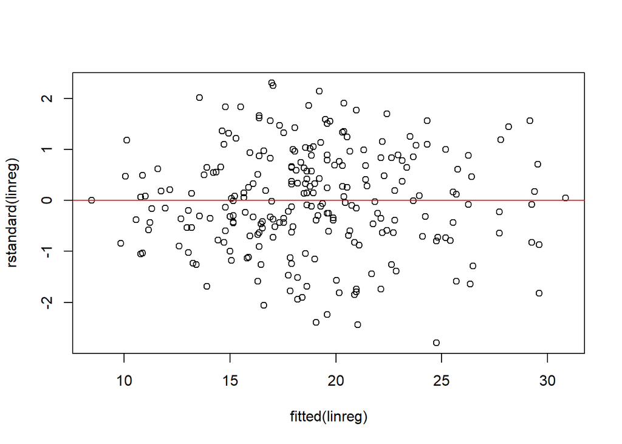

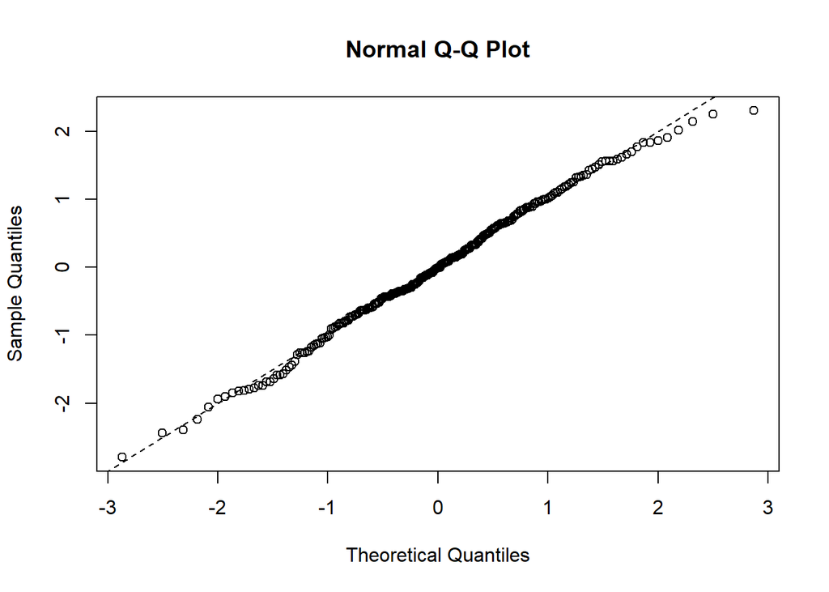

```r
plot(fitted(linreg), rstandard(linreg))
abline(0,0, col = 'Red')

qqnorm(rstandard(linreg))
abline(0,1, lty=2)
```

På residualplottet kigger vi efter, om residualerne ligger symmetrisk omkring 0 for alle prædikterede værdier, og om der er varianshomogenitet.

På QQ-plottet ser vi efter om der er systematiske afvigelser imellem punkterne og den rette linje.

## I dybte gående

**kvadratisk regression, en stikprøve, ensidet ANOVA, lineær regression** Antagelser: * $e_1, ..., e_n$ eller $y_1, ..., y_n$ er uafhængige * Alle $e_i$ eller $y_i$ er normal fordelte * Alle $e_i$ eller $y_i$ har samme spredning * Middelværien har den rette form

**Uafhængihed**  
Antagelsen on uafhængighed er mest et spørgsmål om designet af eksperimentet eller dataindsamlingen. * Er der flere målinger på samme eksperimentelle enhed? * Er individerne i familie med hinanden? * Hører observationerne naturligt sammen i grupper?

Hvis ja, så er der måske problemer med uafhængighedsantagelsen,

**Samme spredning**  
Kontrolleres med residual plot

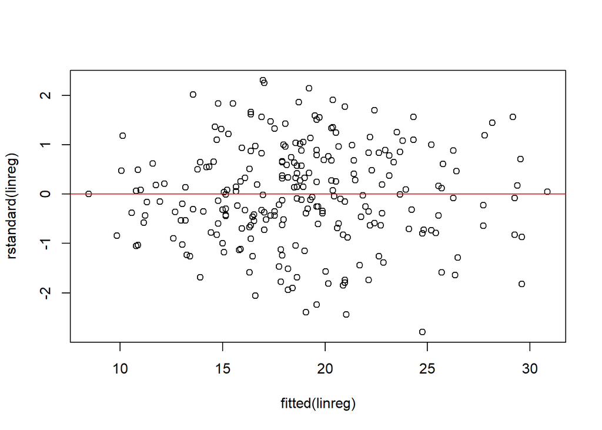

```r
plot(fitted(linreg), rstandard(linreg))
abline(0,0, col = 'Red')
```

Der må være noget mønster i den lodrette variation * Hvis vi kan se en kurve er middelværdien forkert. En parabel i overstående tilfælde vil formentlig betyde vi skal anvende kvadratisk regression * Punkterne udgør en slags trag, viser at spredningen stiger med middelværdien hvilket er et tegn på Variansinhomogenitet

Derudover kan det give mening at være opmærksom på outliers 95% af punkterne bør ligge indenfor (-2, 2)

**Normalt fordelt**

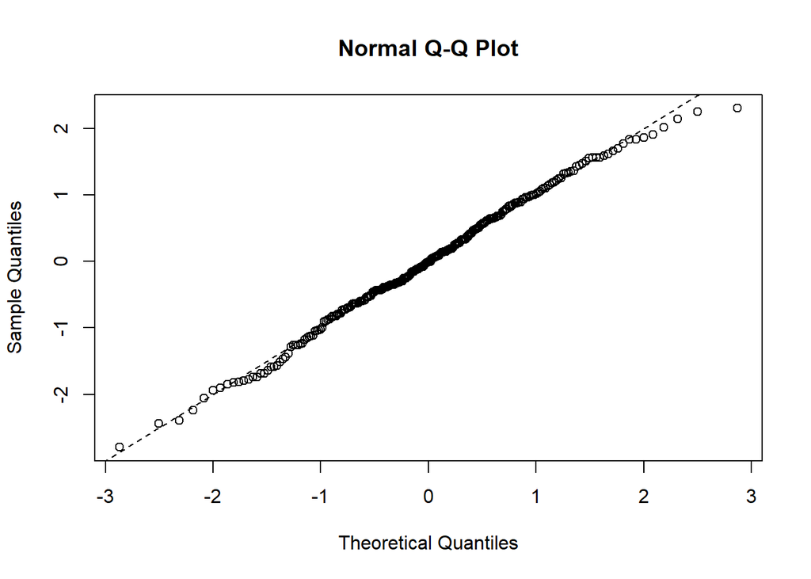

```r
qqnorm(rstandard(linreg))
abline(0,1, lty=2)
```

Der må ikke være nogen systemeatisk afvigelse fra den ligefrem propotionelle linje. (Den er kun ligefrem propotionel fordi vi tester for residual spredningen)

# Grafer og plots

## Scatter

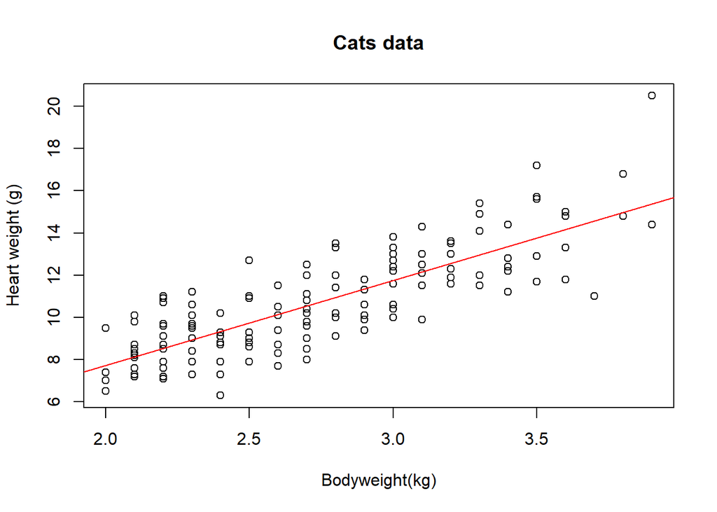

```r
linreg <- lm(Hwt ~ Bwt, data = cats) ### estimer regressionslinje (Kun nødvendig for abline)
plot(cats$Bwt, cats$Hwt, xlab = "Bodyweight(kg)", ylab = "Heart weight (g)", main = "Cats data")
abline(a = -0.3567, b = 4.0341, col = "red") # a = skæring, b = hældning
```

## QQplot

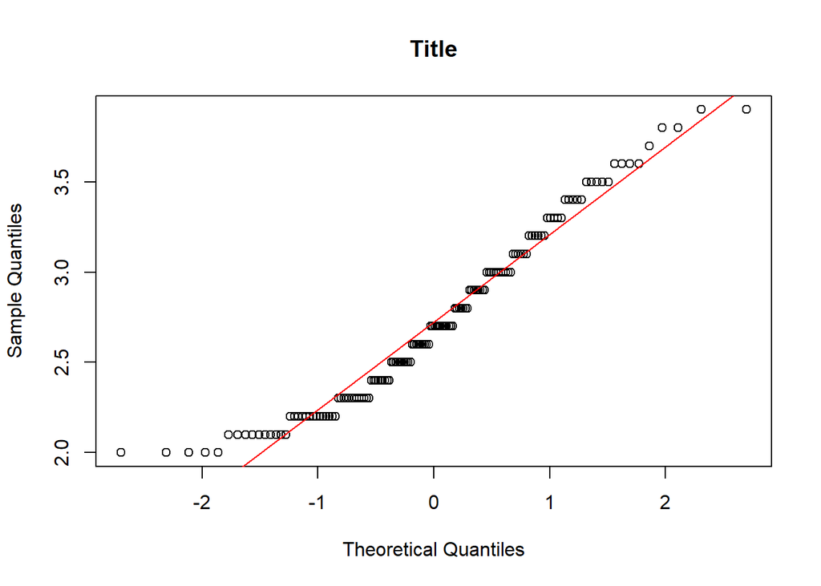

```r
qqnorm(cats$Bwt, main="Title")
abline(mean(cats$Bwt), sd(cats$Bwt), lwd = 1, col = "red")
```

Kontroler efter systematisk afvigelse, hvis der sker en tydelig krumning skal data formentlig log-transformeres.

## Normalfordeling

Kan laves med r-plot

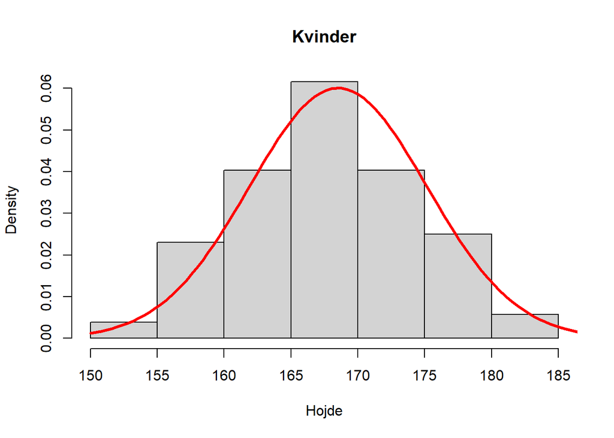

```r
hist(kData$hojde, prob = TRUE, xlab = "Hojde", main = "Kvinder", col = "lightgrey")
f1 <- function(x) dnorm(x, mean = mean(kData$hojde), sd = sd(kData$hojde))
plot(f1, 150, 190, col = "red", add = TRUE, lwd = 3)
```

Men hvis det skal skraveres anvend GGplot

```r
data_mean = 41.5
data_sd = 1.4

p_1 <- pnorm(q = c(42.2), sd = data_sd, mean = data_mean, lower.tail = TRUE) # Mindre end 42
p_2 <- pnorm(q = c(40), sd = data_sd, mean = data_mean, lower.tail = TRUE) # Mindre end 40
p_1 - p_2
```

```
## [1] 0.5494741
```

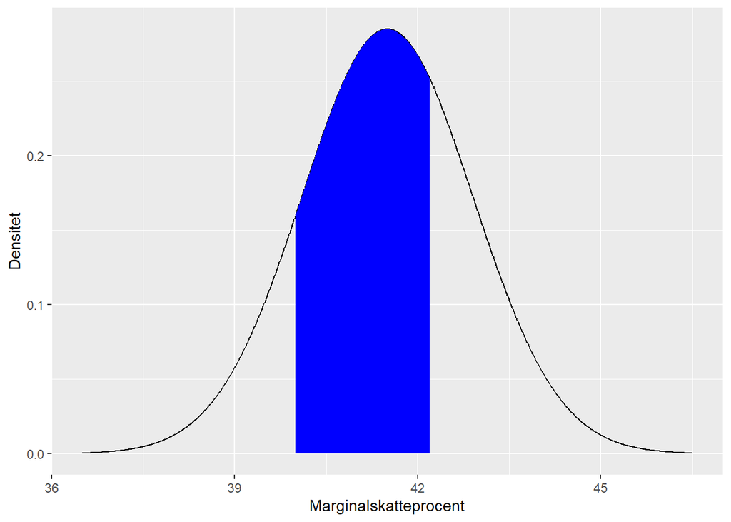

```r
ggplot(data.frame(x = c(data_mean - 5, data_mean + 5)), aes(x)) +
  stat_function(fun = dnorm, n = 1000, args = list(mean = data_mean, sd = data_sd)) +
  # Coloring
  stat_function(fun = dnorm, args = list(mean = data_mean, sd = data_sd),
                xlim = c(40, 42.2), # Defines the interval
                geom = "area", fill = "blue") +
  labs(x = "Marginalskatteprocent", y = "Densitet")
```

## Boxplot

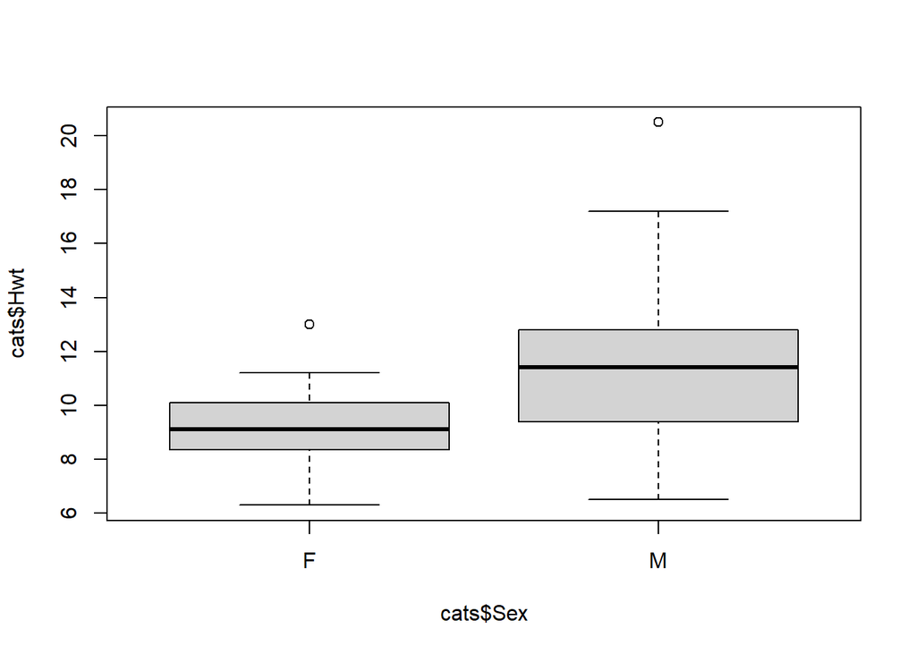

```r
# Kontinuert ~ kategorisk
boxplot(cats$Hwt ~ cats$Sex)
```

En stor between-group variation er et tegn på der er forskel på gruppe gennemsnittene, men hvis within-group varaiationen også er stor, kan det være et tegn på at forskellen skyldes tilfældig variation.

## Histogram

[figure not shown]

```r
hist(log(cats$Hwt), # Data
     xlab="Body weight (kg)", # X label
     main="Cats: Body weight", # Title
     nclass=20, # Antal søjler
     prob=TRUE, # Samlet areal = 1
     col = "blue") # Farve
```

# Generalt

## Fejltyper

Type 1 - Afvise nulhypotesen hvis den er sand Type 2 - Ikke afvise nulhypotesen hvis den er falsk

Bemærk: “Vi konkluderer at der ikke er nogen sammenhæng mellem x og y, selvom der i virkeligheden er en sammenhæng” er en type 2 fejl. Fordi at konkludere at der ikke er nogen sammenhæng er det samme som ikke at afvise hyposten. Og at der er en sammenhæng er det samme som at 0-hypostesen er falsk.

## Konfindensintervaller

# Noter til quiz

## uge 2

### Konfidensintervallet for enkelt stikprøve

**Giver standard error**
$$\hat{y} \pm t_{0.975, n-1} \cdot SE$$
$$n = 7, \mu = 17, SE = 3$$

```r
# mu - qt * s/sqrt(n)
n = 7
mu =17
SE = 3

mu + c(-1, 1) * qt(0.975, df=n-1) * SE
```

```
## [1]  9.659264 24.340736
```

**Givet spredning**
$$\hat{y} \pm t_{0.975, n-1} \cdot \frac{s}{\sqrt{n}}$$

```r
# mu - qt * s/sqrt(n)
n = 7
mu =17
s = 3

mu + c(-1, 1) * qt(0.975, df=n-1) * (s/sqrt(n))
```

```
## [1] 14.22546 19.77454
```

### Find spredning for Normalfordeling givet middelværdi og konfidensinterval på 68%

```r
lower = 50
upper = 62

(upper - lower) / 2
```

```
## [1] 6
```

### Sandsynlighed for Observation over værdi for normal fordeling

Vi får givet middelværdi og spredning

```r
mu = 200 # Middelværdi
s = 40 # Spredning
obs = 190 #Observation

# Under
pnorm(obs, mean = mu, sd = s)
```

```
## [1] 0.4012937
```

```r
#Over
1 - pnorm(obs, mean = mu, sd = s)
```

```
## [1] 0.5987063
```

### Mere end 2 spredninger væk fra middelværdien?

For en normalfordeling fås et nogenlunde 95% interval ved
$$\hat{y} \pm 2 \cdot \frac{s}{\sqrt{n}}$$
Altså ligger 5% af observationerne fra en normalfordelt population mere end 2*spredning vær fra middelværdien

### Sandsylighed mellem 2 værdier for normalfordeing

```r
mu = 15.5 # Middelværdi
s = 3 # Spredning
upper = 16.5 # Til
lower = 14 # Fra

pnorm(upper, mean = mu, sd = s)
```

```
## [1] 0.6305587
```

```r
pnorm(lower, mean = mu, sd = s)
```

```
## [1] 0.3085375
```

```r
cat("\n")
```

```r
pnorm(upper, mean = mu, sd = s) - pnorm(lower, mean = mu, sd = s)
```

```
## [1] 0.3220211
```

### Find den værdi, hvor vi kan forvente at x% af oberservationerne ligger under.

```r
mu = 114.8 # Middelværdi
s = 13.1 # Spredning
x = 0.35 # percentage to check

qnorm(x, mean = mu, sd = s)
```

```
## [1] 109.7523
```

### Beregn SE udfra spredning

SE fra spredning

```r
s = 2
n = 16

s / sqrt(16)
```

```
## [1] 0.5
```

## uge 3

### Bestem t-teststørrelsen og p-værdien for hypotesen i lineær regression

I en lineær regression med 87 datapunkter er hældningen blevet estimeret til 5.12 med en standard error på 3.20. Bestem t-teststørrelsen og p-værdien for hypotesen om at “den sande hældning” er 0

```r
beta = 5.12 #Hældning
SE = 3.2 # Standard error
n = 87 # Antal observationer
hypotese = 0 # hypotesen om at "den sande hældning" er 0


# Test af hypotesen H: beta=4
T = (beta - hypotese) / SE

# Beregning af p-vaerdi
P = 2*(1-pt(T, df = n - 2))

T
```

```
## [1] 1.6
```

```r
P
```

```
## [1] 0.1133091
```

### Konfidensinterval for hældning i lineær regression

I en lineær regression med 104 observationer er hældningen blevet estimeret til 33.2 med en tilhørende standard error på 2.8. Bestem et 95% konfidensinteval for hældningen.

```r
n = 104 # Antal observationer
beta = 33.2 # Hældning
SE = 2.8 # Standard error
int = .95 # Konfidensinterval
conf = 1 - (1 - int) /2
conf
```

```
## [1] 0.975
```

```r
# 2 frihedsgrader for lineær regression
beta + c(-1, 1) * qt(conf, df=n-2) * SE
```

```
## [1] 27.64621 38.75379
```

### Ensidet ANOVA t-fraktil (TODO: Forkert, svaret er 2.002465 )

Ved en ensidet variansanalyse med 20 observationer fra hver af tre forskellige behandlingsgrupper (A, B og C) ønsker man at konstruere et 95 % - konfidensinterval for den gennemsnitlige værdi hørende til målinger fra gruppe A. Angiv værdien af den t-fraktil der indgår i konstruktionen af konfidensintervallet.

```r
n <- 20 # Antal Observationer
k <- 1 # Antal grupper (I gruppe A)

qt(0.975, df = n-1)
```

```
## [1] 2.093024
```

## Uge 4

### Konklusion af p-værdi givet f-fraktil og f-teststørrelse

Man vil sammenligne grupperne i en ensidet ANOVA med 100 observationer og fire grupper med et F-test. Man beregner F-teststørrelsen til 4.19, og 95%-fraktilen i F(3,96) er 2.70. Hvad kan vi sige om p-værdien?

Da
$$\texttt{p-value} = P(F \geq F_{obs})$$

har vi at siden F-teststørrelsen (4.19) er større end fraktilsen (2.70) så er p-værdien er lavere end 0.05 og vi kan afvise at grupperne har samme middelværdi.

### Konklusion af p-værdi givet to f-fraktil og f-teststørrelse

Vi er i gang med at udføre et t-test og får en observeret teststørrelse på T = 1.99. I den relevante t-fordeling er 97.5% fraktilen lig 2.14, mens 95% fraktilen er 1.76.

Da teststørrelse (1.99) ligger mellem 97.5% fraktilen (2.14) og 95% fraktilen er 1.76. (1.76) ligger p-værdien mellem 0.05 og 0.10

- Mindre end 97.5% fraktilen ==> Større end 0.05
- Større end 95% fraktilen ==> Mindre end 0.10

### Bestem t-teststørrelsen og p-værdien for hypotesen i lineær regression

```r
beta = 3.19 #Hældning
SE = .89 # Standard error
n = 52 # Antal observationer
hypotese = 0 # hypotesen om at "den sande hældning" er 0


# Test af hypotesen H: beta=4
T = (beta - hypotese) / SE

# Beregning af p-vaerdi
P = 2*(1-pt(T, df = n - 2))

T
```

```
## [1] 3.58427
```

```r
P
```

```
## [1] 0.0007657704
```

### Sandsylighed for værdi lavere end en værdi givet mean og sd

```r
pnorm(0, mean = 4, sd = 2.8)
```

```
## [1] 0.07656373
```